# Tugas 5 MPDW

Andi Fatihatul Fuadiyah

2023-10-01

```r
library(ggplot2)
library(tsibble)
library(tseries)
library(MASS)
```

## Impor Data

```r
library(readxl)
data <- read_excel("/Users/a.akbaryahya/Documents/PraktikumMPDW/Pertemuan 5/coffee1.xlsx")
data
```

```
## # A tibble: 1,182 × 2
##    Date                Price
##    <dttm>              <dbl>
##  1 2000-01-07 00:00:00 114.
##  2 2000-01-14 00:00:00 113.
##  3 2000-01-21 00:00:00 111.
##  4 2000-01-28 00:00:00 115.
##  5 2000-02-04 00:00:00 113.
##  6 2000-02-11 00:00:00 109.
##  7 2000-02-18 00:00:00 104.
##  8 2000-02-25 00:00:00  98.8
##  9 2000-03-03 00:00:00 104.
## 10 2000-03-10 00:00:00 106.
## # ℹ 1,172 more rows
```

# Mengubah data agar terbaca sebagai data deret waktu

```r
data.ts <- ts(data$`Price`)
data.ts
```

```
## Time Series:
## Start = 1
## End = 1182
## Frequency = 1
##    [1] 114.15 112.55 111.20 114.70 112.90 108.80 104.30  98.80 104.35 106.10
##   [11] 106.10 103.15 103.70  99.60  92.65  97.75  95.30  96.85  91.80  97.95
##   [21]  99.20  95.55  91.85  87.25  87.05  84.85  80.80  89.15  96.65  87.40
##   [31]  85.60  80.65  78.40  77.75  75.00  77.40  76.25  78.00  83.00  79.45
##   [41]  81.05  84.15  75.60  73.60  74.15  68.55  68.30  67.00  63.65  62.90
##   [51]  65.40  65.55  64.35  65.00  68.30  67.10  63.20  62.65  59.80  64.95
##   [61]  63.30  61.70  59.00  60.10  60.30  58.10  57.60  57.15  60.95  63.65
##   [71]  64.95  63.80  59.90  57.90  58.15  59.40  55.90  56.10  53.85  52.05
##   [81]  53.75  51.30  50.40  48.40  54.35  50.95  50.50  48.50  49.05  48.30
##   [91]  46.65  44.70  43.85  43.40  45.40  44.70  48.65  46.40  42.60  43.00
##  [101]  43.80  46.65  46.20  48.55  49.55  47.40  45.90  45.45  44.55  44.10
```

[output cut: 108 more lines]

# Membuat plot data deret waktu

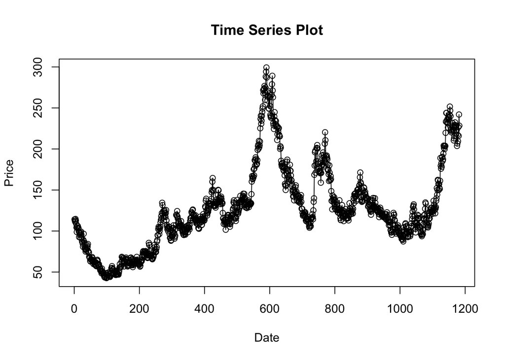

```r
ts.plot(data.ts, xlab="Date", ylab="Price",
        main = "Time Series Plot")
points(data.ts)
```

```r
mean(data.ts)
```

```
## [1] 126.5626
```

### Plot ACF

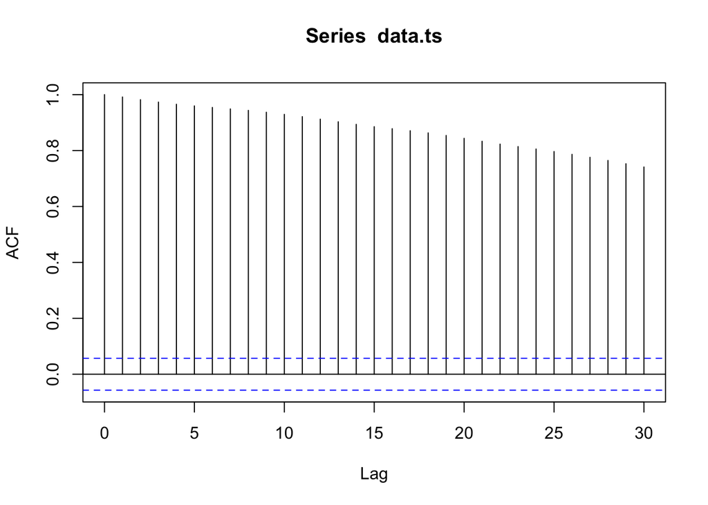

```r
acf(data.ts)
```

Berdasarkan plot ACF, terlihat bahwa plot ACF pada data tersebut *tails off slowly* yang menandakan data tidak stasioner dalam rataan

### Uji ADF

```r
tseries::adf.test(data.ts)
```

```
##
##  Augmented Dickey-Fuller Test
##
## data:  data.ts
## Dickey-Fuller = -2.0429, Lag order = 10, p-value = 0.5601
## alternative hypothesis: stationary
```

### Plot Box-Cox

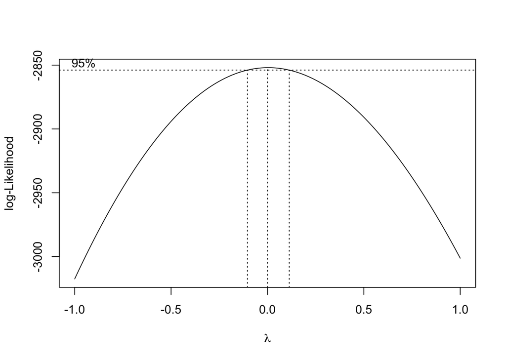

```r
index <- seq(1:1182)
bc = boxcox(data.ts~index, lambda = seq(-1,1,by=0.01))
```

```r
#Nilai Rounded Lambda
lambda <- bc$x[which.max(bc$y)]
lambda
```

```
## [1] 0
```

```r
#SK
bc$x[bc$y > max(bc$y) - 1/2 * qchisq(.95,1)]
```

```
##  [1] -0.10 -0.09 -0.08 -0.07 -0.06 -0.05 -0.04 -0.03 -0.02 -0.01  0.00  0.01
## [13]  0.02  0.03  0.04  0.05  0.06  0.07  0.08  0.09  0.10  0.11
```

Gambar di atas menunjukkan nilai *rounded value* ($\lambda$) optimum sebesar **0** dan pada selang kepercayaan 95% nilai memiliki batas bawah **-0,10** dan batas atas **0,11**. Selang tersebut tidak memuat nilai satu sehingga dapat dikatakan bahwa data tidak stasioner dalam ragam.

### Partisi Data

#### Bagian 1

```r
dt_stas1 <- data.ts[1:591] |> ts()
mean(dt_stas1)
```

```
## [1] 104.2177
```

```r
var(dt_stas1)
```

```
## [1] 2131.461
```

#### Plot Time Series

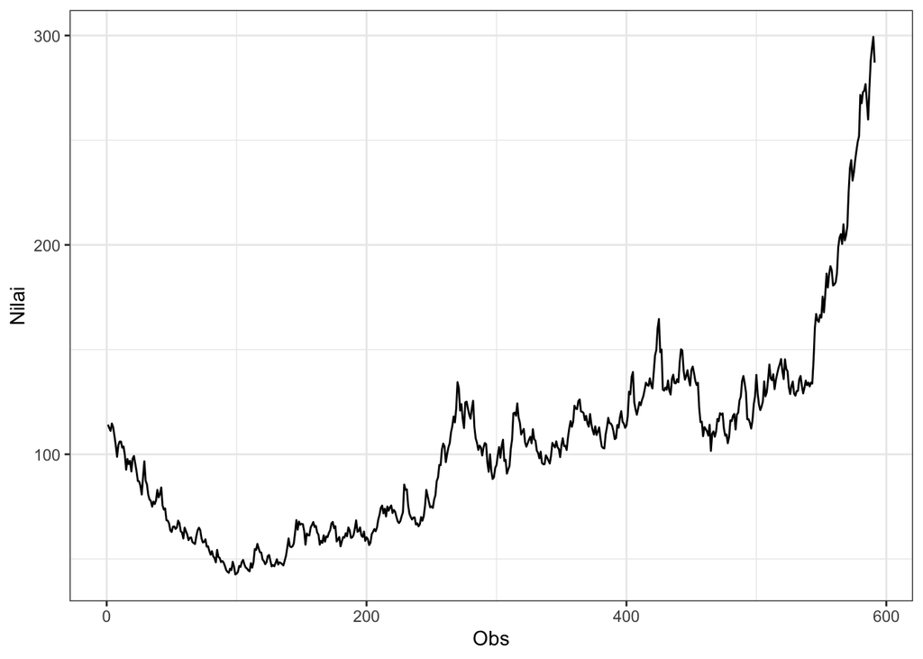

```r
dt_stas1 |> as_tsibble() |>
  ggplot(aes(x = index, y = value)) +
  geom_line() + theme_bw() +
  xlab("Obs") + ylab("Nilai")
```

Plot deret waktu di atas menunjukkan bahwa data tidak stasioner dalam rataan, ditandai dengan data yang tidak menyebar di sekitar nilai tengahnya (104.2177) dan tidak stasioner dalam ragam, ditandai dengan lebar pita yang cenderung berbeda.

#### Plot ACF

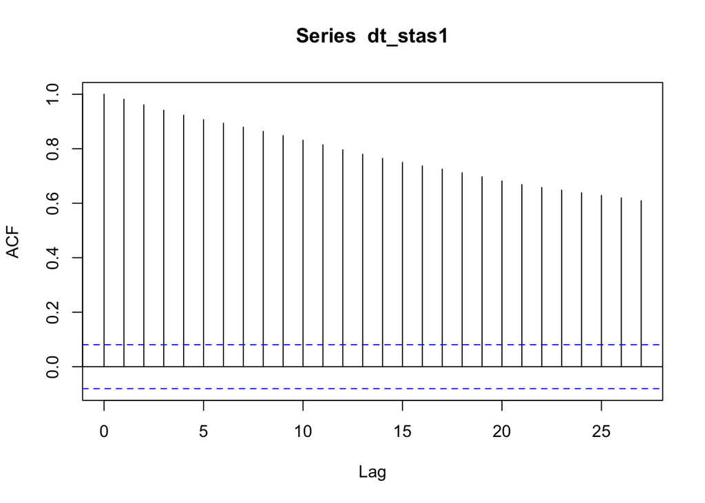

```r
acf(dt_stas1)
```

Berdasarkan plot ACF, terlihat bahwa plot ACF pada data tersebut cenderung *tails off slowly* yang menandakan data tidak stasioner dalam rataan

#### Uji ADF

```r
tseries::adf.test(dt_stas1)
```

```
##
##  Augmented Dickey-Fuller Test
##
## data:  dt_stas1
## Dickey-Fuller = 0.36184, Lag order = 8, p-value = 0.99
## alternative hypothesis: stationary
```

$H_0$ : Data tidak stasioner dalam rataan

$H_1$ : Data stasioner dalam rataan

Berdasarkan uji ADF tersebut, didapat *p-value* sebesar 0.99 yang lebih besar dari taraf nyata 5% sehingga terima $H_0$ dan menandakan bahwa data tidak stasioner dalam rataan. Hal ini sesuai dengan hasil eksplorasi menggunakan plot time series dan plot ACF.

#### Plot Boxcox

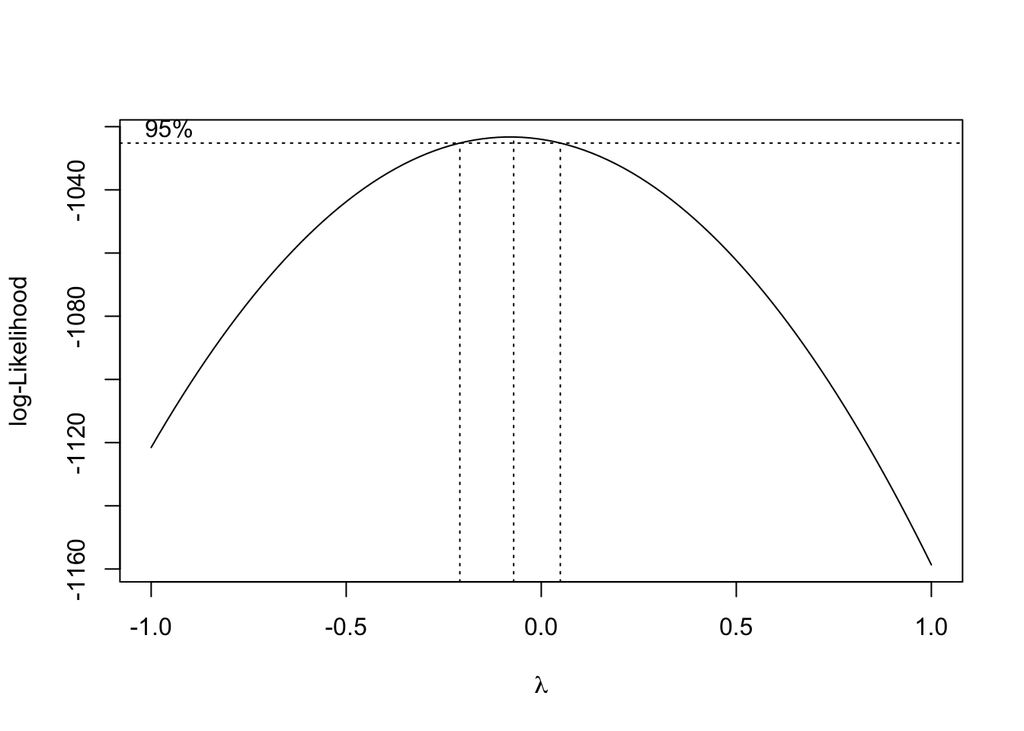

```r
index <- seq(1:591)
bc = boxcox(dt_stas1~index, lambda = seq(-1,1,by=1))
```

```r
#Nilai Rounded Lambda
lambda <- bc$x[which.max(bc$y)]
lambda
```

```
## [1] -0.07070707
```

```r
#SK
bc$x[bc$y > max(bc$y) - 1/2 * qchisq(.95,1)]
```

```
##  [1] -0.19191919 -0.17171717 -0.15151515 -0.13131313 -0.11111111 -0.09090909
##  [7] -0.07070707 -0.05050505 -0.03030303 -0.01010101  0.01010101  0.03030303
```

Gambar di atas menunjukkan nilai *rounded value* ($\lambda$) optimum sebesar **-0.07** dan pada selang kepercayaan 95% nilai memiliki batas bawah **-0.19** dan batas atas **0.03**. Selang tersebut tidakmemuat nilai satu sehingga dapat dikatakan bahwa data tidak stasioner dalam ragam.

#### Bagian 2

```r
dt_stas2 <- data.ts[592:1182] |> ts()
mean(dt_stas2)
```

```
## [1] 148.9074
```

```r
var(dt_stas2)
```

```
## [1] 1956.604
```

#### Plot Time Series

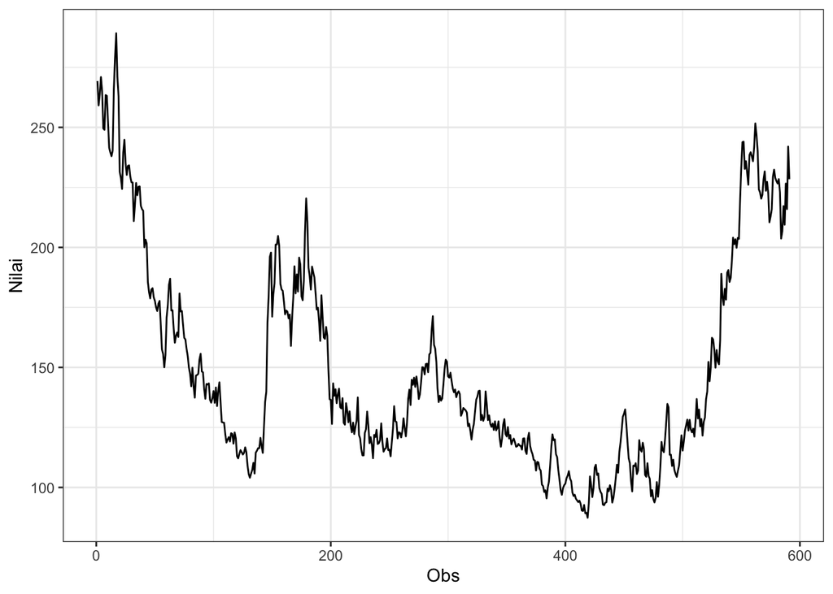

```r
dt_stas2 |> as_tsibble() |>
  ggplot(aes(x = index, y = value)) +
  geom_line() + theme_bw() +
  xlab("Obs") + ylab("Nilai")
```

Plot deret waktu di atas menunjukkan bahwa data tidak stasioner dalam rataan, ditandai dengan data yang menyebar tidak di sekitar nilai tengahnya (148.9074) serta tidak stasioner dalam ragam, ditandai dengan lebar pita yang cenderung berbeda

#### Plot ACF

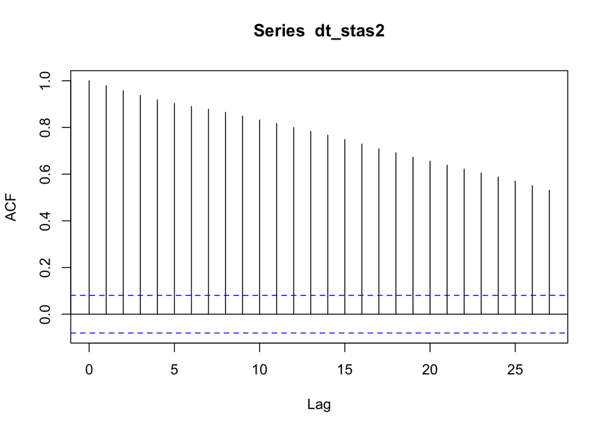

```r
acf(dt_stas2)
```

Berdasarkan plot ACF, terlihat bahwa plot ACF pada data tersebut cenderung *tails off slowly* yang menandakan data tidak stasioner dalam rataan

#### Uji ADF

```r
adf.test(dt_stas2)
```

```
##
##  Augmented Dickey-Fuller Test
##
## data:  dt_stas2
## Dickey-Fuller = -1.741, Lag order = 8, p-value = 0.6879
## alternative hypothesis: stationary
```

$H_0$ : Data tidak stasioner dalam rataan $H_1$ : Data stasioner dalam rataan

Berdasarkan uji ADF tersebut, didapat *p-value* sebesar 0.6879 yang lebih besar dari taraf nyata 5% sehingga terima $H_0$ dan menandakan bahwa data tidak stasioner dalam rataan. Hal ini sesuai dengan hasil eksplorasi menggunakan plot time series dan plot ACF.

#### Plot Boxcox

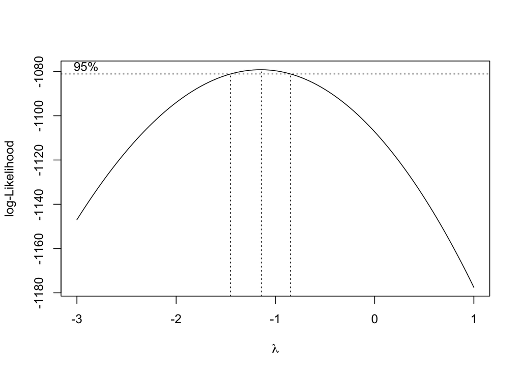

```r
index <- seq(592:1182)
bc = boxcox(dt_stas2~index, lambda = seq(-3,1,by=1))
```

```r
#Nilai Rounded Lambda
lambda <- bc$x[which.max(bc$y)]
lambda
```

```
## [1] -1.141414
```

```r
#SK
bc$x[bc$y > max(bc$y) - 1/2 * qchisq(.95,1)]
```

```
##  [1] -1.4242424 -1.3838384 -1.3434343 -1.3030303 -1.2626263 -1.2222222
##  [7] -1.1818182 -1.1414141 -1.1010101 -1.0606061 -1.0202020 -0.9797980
## [13] -0.9393939 -0.8989899 -0.8585859
```

Gambar di atas menunjukkan nilai *rounded value* ($\lambda$) optimum sebesar **-1.14** dan pada selang kepercayaan 95% nilai memiliki batas bawah **-1.42** dan batas atas **-0.85**. Selang tersebut tidak memuat nilai satu sehingga dapat dikatakan bahwa data tidak stasioner dalam ragam.